# Métricas essenciais de Biodiversidade

**Um script criado pelo Prof Marcos Vital, para a [Academia do R](https://www.instagram.com/academia_do_r/)**

*Este script foi escrito usando [R Markdown](https://rmarkdown.rstudio.com/) no [RStudio](https://www.rstudio.com/) versão 1.4.1106, e testado em R versão 4.1.0.*

### O que é este script?

Este script foi criado para que qualquer pessoa possa realizar uma avaliação automática de diversas métricas básicas (mas essenciais) tipicamente usadas em análises de Biodiversidade.

A maneira mais fácil de usar, especialmente se você for iniciante no R, é salvar os seus dados em um arquivo com o nome `dadosbio.csv` e salvá-lo na pasta de trabalho que estiver sendo usada no R.

Você também irá precisar do arquivo `curvacum.R`, que carrega uma função personalizada para criação do gráfico de curva de acúmulo de espécies.

As instruções detalhadas de como usá-lo foram exibidas na última aula da **Maratona de Análise de Biodiversidade no R**, que foi promovida pela [Academia do R](https://www.instagram.com/academia_do_r/)

Na sua primeira tentativa de utilizar este script, recomendo fortemente que use o arquivo de dados de exemplo que foi fornecido junto com ele durante a aula. Depois de conseguir fazer tudo com o exemplo, tente com os seus próprios dados! ;)

Para que o script funcione, você deve ter o pacote `vegan` instalado, além do pacote `RMarkdown` e todas as suas dependências.

### Lendo os dados

Os seus dados devem estar em formato csv, separado por vírgulas. Caso esteja com separação em ponto e vírgula, veja a explicação após o comando para alterar.

O nome do arquivo deve ser `dadosbio.csv`, a não ser que você prefira alterar o comando a seguir, ok? E não se esqueça de conferir se ele está salvo na pasta de trabalho que estiver sendo usada pelo R no momento.

A estrutura dos dados neste arquivo deve, obrigatoriamente, seguir o padrão “unidades amostrais nas linhas, espécies nas colunas”. Na dúvida, veja o arquivo de exemplo.

- Se o seu arquivo usar ponto e vírgula como separador de colunas, mude sep para “;”
- Se os seus dados usarem separador decimal, use ponto como separador, ou altered dec para “,” caso use vírgulas.

**Conferindo rapidemente o tamanho do arquivo: ele tem 30 linhas e 43 colunas.**

Se a descrição acima não estiver correta, confira o arquivo, seu formato, o local que está salvo, e comece de novo, ok?

### Riqueza de espécies por unidade amostral

Vamos começar calculando métricas básicas sobre o número de espécies encontradas na nossa amostra.

- No total, temos 43 espécies coletadas.
- O número total de espécies por unidade amostral variou de 16 até 27.
- Em média, são 20.8666667 espécies por unidade amostral, com um desvio padrão de 3.2982057, de um total de 30 unidades amostrais coletadas

**Vamos ver um histograma do número de espécies por unidade amostral:**

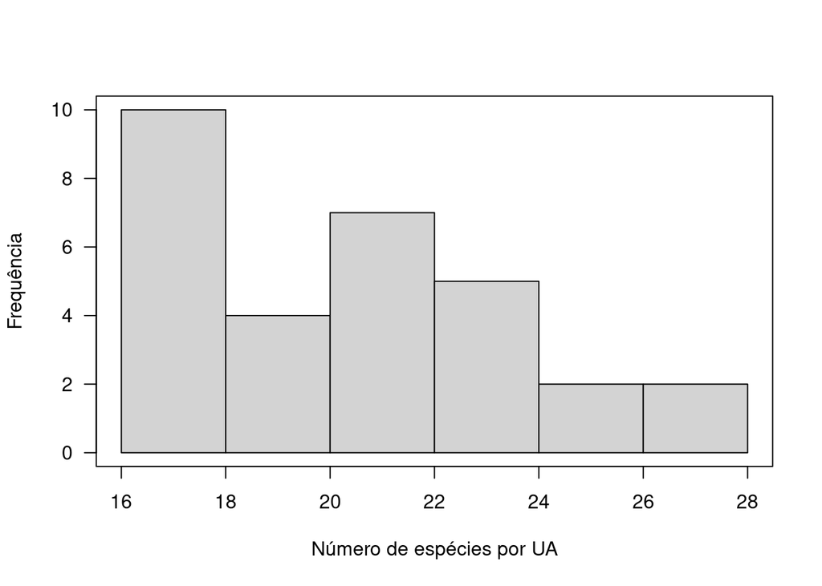

**Agora veja em detalges o total de espécies em cada unidade amostral:**

```
##    Unidade Amostral Número de espécies
## 1                 1                 17
## 2                 2                 23
## 3                 3                 16
## 4                 4                 22
## 5                 5                 27
## 6                 6                 22
## 7                 7                 22
## 8                 8                 18
## 9                 9                 25
## 10               10                 16
## 11               11                 21
## 12               12                 18
## 13               13                 18
## 14               14                 27
```

[output cut: 16 more lines]

**Também podemos colocar isto tudo em um gráfico de barras simples:**

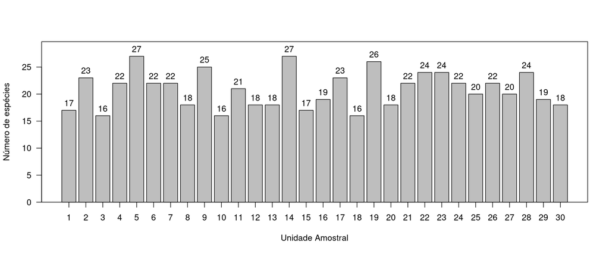

### Total de indivíduos por unidade amostral

Agora vamos avaliar a quantidade de organismos coletados em cada unidade amostral (dependendo do contexto, esta quantidade pode representar abundância, densidade, cobertura, biomassa, etc.). O texto a seguir considera que estamos trabalhando com abundância, mas é fácil adaptar para outras medidas.

- No total, foram 1927 indivíduos coletados nas 30 unidades amostrais.
- O total de indivíduos de cada unidade amostral variou de 26 até 108.
- Em média, foram 64.2333333 indivíduos por unidade amostral, com um desvio padrão de 21.9241378 indivíduos

**Veja o histograma do total de indivíduos por unidade amostral:**

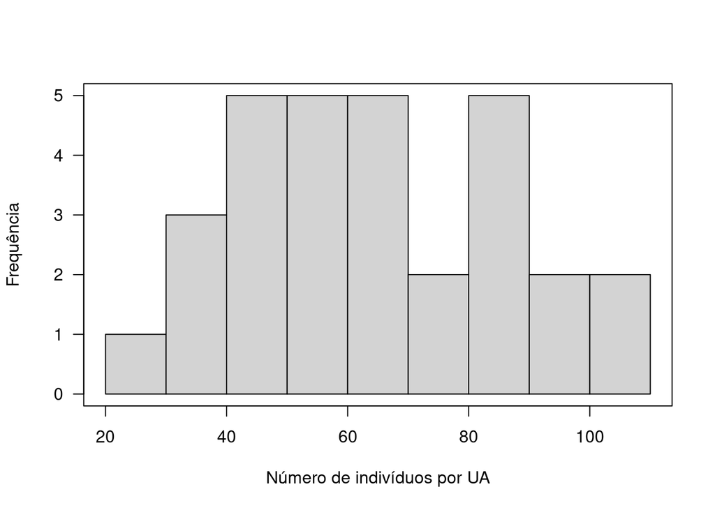

**Veja em detalhe o total de indivíduos por unidade amostral:**

```
##    Unidade Amostral Total de indivíduos
## 1                 1                  37
## 2                 2                  69
## 3                 3                  33
## 4                 4                  79
## 5                 5                  52
## 6                 6                  46
## 7                 7                  50
## 8                 8                  47
## 9                 9                  65
## 10               10                  26
## 11               11                  63
## 12               12                  44
## 13               13                  44
## 14               14                  61
```

[output cut: 16 more lines]

**E os mesmos totais, representados em um gráfico de barras:**

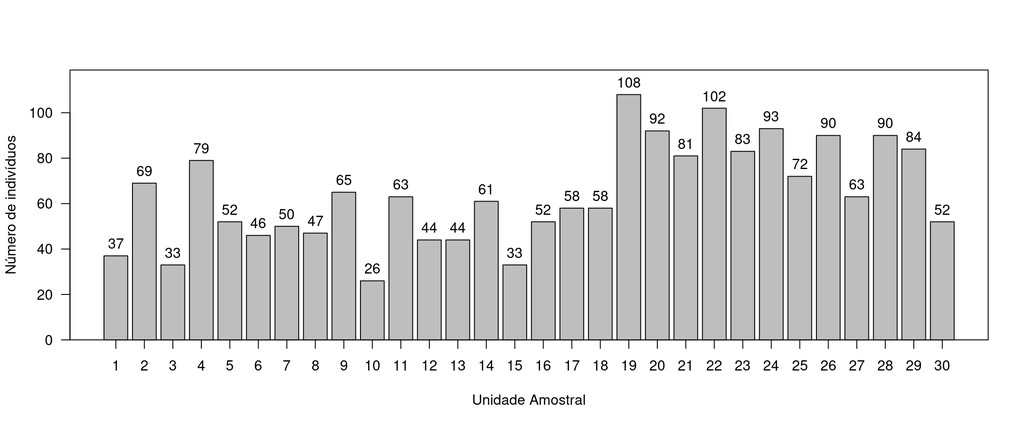

### Quantidade por espécie e diagrama de rank-abundância

Agora vamos avaliar o quanto de representação temos para cada espécie. Mais uma vez, trabalhando com abundância como base.

- Já sabemos que são 1927 indivíduos coletados de um total de 43 espécies.
- O total de indivíduos por espécie variou entre 1 e 228.
- Em média, foram 44.8139535 indivíduos por espécie, com um desvio padrão de 50.6995143 indivíduos.

**Vamos ao histograma do total de invidíduos por espécie:**

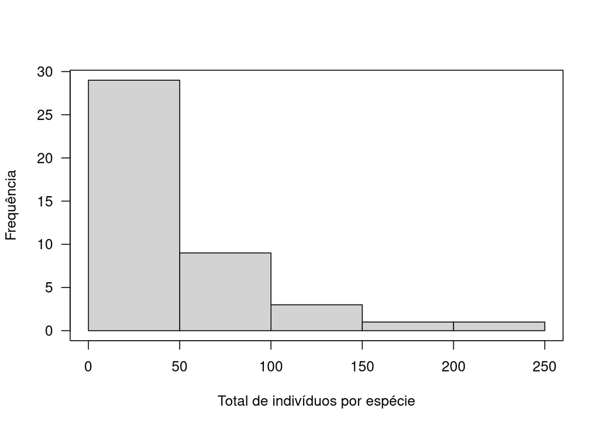

**Veja em detalhe o total de indivíduos para cada espécie:**

```
##       Total de indivíduos
## sp.1                  103
## sp.2                   33
## sp.3                  150
## sp.4                  114
## sp.5                   54
## sp.6                  228
## sp.7                   64
## sp.8                   99
## sp.9                   55
## sp.10                  50
## sp.11                  89
## sp.12                  71
## sp.13                  95
## sp.14                 183
## sp.15                  36
## sp.16                  26
## sp.17                  29
## sp.18                  27
## sp.19                  20
## sp.20                  18
## sp.21                  74
## sp.22                  55
## sp.23                  29
## sp.24                  16
## sp.25                  30
## sp.26                  19
## sp.27                   5
## sp.28                   8
## sp.29                   7
## sp.30                   3
## sp.31                   8
## sp.32                  20
## sp.33                   6
## sp.34                   4
## sp.35                  13
## sp.36                   1
## sp.37                   8
## sp.38                  16
## sp.39                   5
## sp.40                   3
## sp.41                  19
## sp.42                  23
## sp.43                  11
```

**Diagrama de rank-abundância em gráfico de barras:**

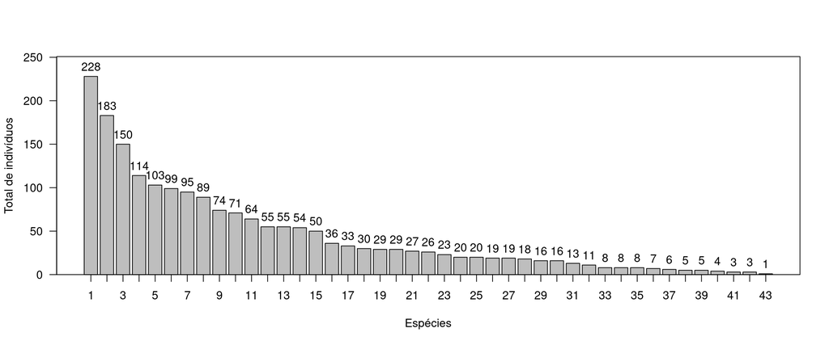

### Calculando alguns índices de diversidade

Vamos trabalhar com dois índices amplamente usados: o índice de Shannon e o índice de Simpson. Para ambos, vamos calcular o valor total para toda a amostra, e o valor médio (com seu desvio padrão) para cada unidade amostral.

Os valores de Simpson serão apresentados na forma original, variando de 0 a 1, na qual valores mais baixos indicam maior diversidade (este formato é eventualmente chamado de índice de dominância de Simpson).

**Índice de Shannon**

- O índice de diversidade de Shannon da amostra completa é de 3.2520821.
- O valor médio para cada unidade amostral é de 2.8067941, com desvio padrão de 0.1298341

### Estimando a riqueza de espécies e pensando em suficiência amostral

Vamos começar calculando os estimadores de riqueza de espécies mais usados em estudos de Biodiversidade:

```
##     Species     chao  chao.se    jack1 jack1.se    jack2     boot   boot.se  n
## All      43 44.93333 3.625833 44.93333 1.367073 45.89885 44.00036 0.9298509 30
```

**Vamos agora calcular uma curva de acúmulo usando o método de rarefação:**

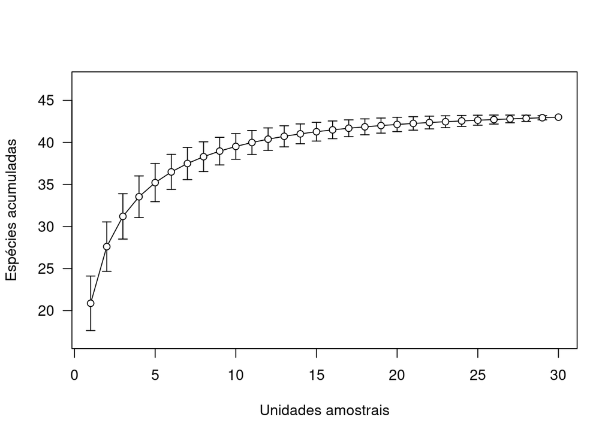

**É fundamental que os valores por trás da curva sejam avaliados com cuidado, então vamos conferí-los:**

```
## Species Accumulation Curve
## Accumulation method: exact
## Call: specaccum(comm = dados)
##
##
## Sites     1.00000  2.00000  3.00000  4.00000  5.0000  6.00000  7.00000  8.00000
## Richness 20.86667 27.60690 31.20172 33.53950 35.2172 36.49044 37.49227 38.30090
## sd        3.24277  2.93795  2.69864  2.47518  2.2681  2.08222  1.91727  1.77152
##
## Sites     9.00000 10.00000 11.00000 12.00000 13.00000 14.00000 15.00000
## Richness 38.96591 39.52054 39.98806 40.38544 40.72546 41.01808 41.27123
## sd        1.64251  1.52793  1.42586  1.33470  1.25305  1.17969  1.11348
##
## Sites    16.00000 17.00000 18.00000 19.00000 20.00000 21.00000 22.00000
## Richness 41.49135 41.68377 41.85292 42.00254 42.13581 42.25540 42.36361
## sd        1.05330  0.99805  0.94658  0.89776  0.85047  0.80355  0.75590
##
## Sites    23.00000 24.00000 25.00000 26.00000 27.00000 28.00000 29.00000 30
## Richness 42.46239 42.55339 42.63801 42.71742 42.79261 42.86437 42.93333 43
## sd        0.70629  0.65355  0.59613  0.53228  0.45881  0.37130  0.24944  0
```

### E agora?

Este script foi construído pelo Prof Marcos Vital como parte do material da Maratona de Análise de Biodiversidade no R, promovido pela [Academia do R](https://www.instagram.com/academia_do_r/).

Você pode alterar, remixar, reconstruir ou modificar este script como quiser. Pense nele como um modelo a ser trabalhado, e não a ser seguido rigorosamente.

Abraços, e que todos tenham um excelente aprendizado com o R!

Prof Marcos